# Chi-Cuadrado

Henri Gerard Gabert Hidalgo

2024-06-07

## Importación de paquetes

```r
library(readr)
library(tidyverse)
```

```r
library(ggplot2)
library(stats)
library(corrplot)
```

## Carga de la base

```r
df <- read_csv("F:/Proyecto Estadistica/heart_disease_health_indicators_BRFSS2015.csv")
```

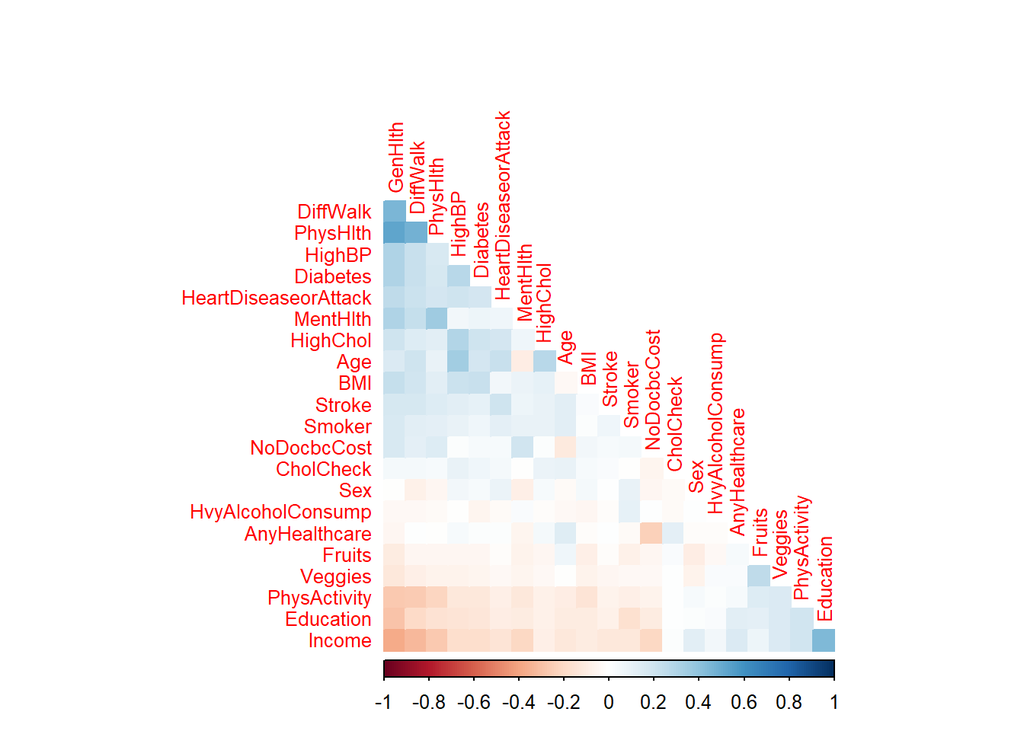

```r
correlation_matrix <- cor(df)
corrplot(correlation_matrix, method = 'color', order = 'FPC', type = 'lower', diag = FALSE,
          tl.cex = 0.8, # Tamaño de las etiquetas de texto
         cl.cex = 0.8, # Tamaño de la leyenda de colores
         number.cex = 0.7) # Tamaño de los números de correlación
```

Al observar el gráfico de correlación se ve la relación lineal entre dos variables, es decir si existe una relación en la que una variable cambia en proporción constante con respecto a la otra, que una suba implica que la otra suba, que una baje implica que la otra baje cuando hablamos de correlación positiva, sin embargo le negativa es que hagan lo contrario es decir si una sube la otra baja, etc.

Sin embargo como logramos apreciar no existe mucha correlación con las variables del data frame, por lo que vamos a realizar pruebas de hipótesis para ver si del todo no tienen relación o si existe dependencia entre ellas.

## Desarrollo

La prueba de chi-cuadrado se utiliza para encontrar si existe depenencia o no con las variables que poseemos, además es usada con variables categóricas de 2 o más categorías, por lo que es ideal para la mayoría de nuestras variables, depués de tener nuestras tablas de contingencias, utilizando un método de vectorización aplicamos la función chisq.test() del paquete stats a todas las tablas de contingencias realizadas.

Según las notas del curso para estas pruebas la hipótesis nula es que las dos variables son independientes.

```r
df <- df %>% mutate(across(-HeartDiseaseorAttack, as.factor))

# Obtener los nombres de las columnas del df
variables <- colnames(df)[colnames(df) != "HeartDiseaseorAttack"]

# Realizar pruebas chi-cuadrado de Pearson para cada variable
for (variable in variables) {
  tabla <- table(df[[variable]], df$HeartDiseaseorAttack)

  resultado <- chisq.test(tabla)

  cat("Resultados para la variable:", variable, "\n")
  print(resultado)

  if (resultado$p.value < 0.05) {
    cat("Rechazamos la hipótesis nula. Hay una relación estadisticamente significativa entre", variable, "y HeartDiseaseorAttack.\n\n")
  } else {
    cat("No rechazamos la hipótesis nula. No hay suficiente evidencia para afirmar que hay una relación estadisticamente significativa entre", variable, "y HeartDiseaseorAttack.\n\n")
  }
}
```

```
## Resultados para la variable: HighBP
##
##  Pearson's Chi-squared test with Yates' continuity correction
##
## data:  tabla
## X-squared = 11118, df = 1, p-value < 2.2e-16
##
## Rechazamos la hipótesis nula. Hay una relación estadisticamente significativa entre HighBP y HeartDiseaseorAttack.
##
## Resultados para la variable: HighChol
##
##  Pearson's Chi-squared test with Yates' continuity correction
##
## data:  tabla
## X-squared = 8288, df = 1, p-value < 2.2e-16
##
## Rechazamos la hipótesis nula. Hay una relación estadisticamente significativa entre HighChol y HeartDiseaseorAttack.
##
## Resultados para la variable: CholCheck
##
##  Pearson's Chi-squared test with Yates' continuity correction
##
## data:  tabla
## X-squared = 494.93, df = 1, p-value < 2.2e-16
##
## Rechazamos la hipótesis nula. Hay una relación estadisticamente significativa entre CholCheck y HeartDiseaseorAttack.
```

```
## Resultados para la variable: BMI
##
##  Pearson's Chi-squared test
##
## data:  tabla
## X-squared = 1251.2, df = 83, p-value < 2.2e-16
##
## Rechazamos la hipótesis nula. Hay una relación estadisticamente significativa entre BMI y HeartDiseaseorAttack.
##
## Resultados para la variable: Smoker
##
##  Pearson's Chi-squared test with Yates' continuity correction
##
## data:  tabla
## X-squared = 3321.6, df = 1, p-value < 2.2e-16
##
## Rechazamos la hipótesis nula. Hay una relación estadisticamente significativa entre Smoker y HeartDiseaseorAttack.
##
## Resultados para la variable: Stroke
##
##  Pearson's Chi-squared test with Yates' continuity correction
##
## data:  tabla
## X-squared = 10451, df = 1, p-value < 2.2e-16
##
## Rechazamos la hipótesis nula. Hay una relación estadisticamente significativa entre Stroke y HeartDiseaseorAttack.
##
## Resultados para la variable: Diabetes
##
##  Pearson's Chi-squared test
##
## data:  tabla
## X-squared = 8244.9, df = 2, p-value < 2.2e-16
##
## Rechazamos la hipótesis nula. Hay una relación estadisticamente significativa entre Diabetes y HeartDiseaseorAttack.
##
## Resultados para la variable: PhysActivity
##
##  Pearson's Chi-squared test with Yates' continuity correction
##
```

[output cut: 43 more lines]

```
##  Pearson's Chi-squared test with Yates' continuity correction
##
## data:  tabla
## X-squared = 243.4, df = 1, p-value < 2.2e-16
##
## Rechazamos la hipótesis nula. Hay una relación estadisticamente significativa entre NoDocbcCost y HeartDiseaseorAttack.
##
## Resultados para la variable: GenHlth
##
##  Pearson's Chi-squared test
##
## data:  tabla
## X-squared = 19008, df = 4, p-value < 2.2e-16
##
## Rechazamos la hipótesis nula. Hay una relación estadisticamente significativa entre GenHlth y HeartDiseaseorAttack.
```

```
## Warning in chisq.test(tabla): Chi-squared approximation may be incorrect
```

```
## Resultados para la variable: MentHlth
##
##  Pearson's Chi-squared test
##
## data:  tabla
## X-squared = 1299.5, df = 30, p-value < 2.2e-16
##
## Rechazamos la hipótesis nula. Hay una relación estadisticamente significativa entre MentHlth y HeartDiseaseorAttack.
```

```
## Warning in chisq.test(tabla): Chi-squared approximation may be incorrect
```

```
## Resultados para la variable: PhysHlth
##
##  Pearson's Chi-squared test
##
## data:  tabla
## X-squared = 8866.2, df = 30, p-value < 2.2e-16
##
## Rechazamos la hipótesis nula. Hay una relación estadisticamente significativa entre PhysHlth y HeartDiseaseorAttack.
##
## Resultados para la variable: DiffWalk
##
##  Pearson's Chi-squared test with Yates' continuity correction
##
## data:  tabla
## X-squared = 11476, df = 1, p-value < 2.2e-16
##
## Rechazamos la hipótesis nula. Hay una relación estadisticamente significativa entre DiffWalk y HeartDiseaseorAttack.
##
## Resultados para la variable: Sex
##
##  Pearson's Chi-squared test with Yates' continuity correction
##
## data:  tabla
## X-squared = 1879.8, df = 1, p-value < 2.2e-16
##
## Rechazamos la hipótesis nula. Hay una relación estadisticamente significativa entre Sex y HeartDiseaseorAttack.
##
## Resultados para la variable: Age
##
##  Pearson's Chi-squared test
##
## data:  tabla
## X-squared = 13731, df = 12, p-value < 2.2e-16
##
## Rechazamos la hipótesis nula. Hay una relación estadisticamente significativa entre Age y HeartDiseaseorAttack.
##
## Resultados para la variable: Education
##
##  Pearson's Chi-squared test
##
## data:  tabla
## X-squared = 2589.8, df = 5, p-value < 2.2e-16
##
## Rechazamos la hipótesis nula. Hay una relación estadisticamente significativa entre Education y HeartDiseaseorAttack.
##
## Resultados para la variable: Income
##
##  Pearson's Chi-squared test
##
## data:  tabla
## X-squared = 5277.6, df = 7, p-value < 2.2e-16
##
## Rechazamos la hipótesis nula. Hay una relación estadisticamente significativa entre Income y HeartDiseaseorAttack.
```

Depués de observar los P-Value resultantes, nos damos cuenta que a pesar de poseer un X-squared disitinto o tener distintos grados de libertad, todas poseen p-value<2.2e-16 por lo tanto rechazamos la hipotesis nula y por tanto hay dependencia, además los Warning: Chi-squared approximation may be incorrect, son completamente normales dado que son las variables no categóricas del data frame.

## Columnas de base

```r
colnames(df)
```

```
##  [1] "HeartDiseaseorAttack" "HighBP"               "HighChol"
##  [4] "CholCheck"            "BMI"                  "Smoker"
##  [7] "Stroke"               "Diabetes"             "PhysActivity"
## [10] "Fruits"               "Veggies"              "HvyAlcoholConsump"
## [13] "AnyHealthcare"        "NoDocbcCost"          "GenHlth"
## [16] "MentHlth"             "PhysHlth"             "DiffWalk"
## [19] "Sex"                  "Age"                  "Education"
## [22] "Income"
```

## Creación de columnas nuevas

```r
df <- df %>%
  mutate(High_Chol_BP = case_when(
    HighChol == 0 & HighBP == 0 ~ 0,
    HighChol == 1 & HighBP == 1 ~ 1,
    HighChol == 1 & HighBP == 0 ~ 2,
    HighChol == 0 & HighBP == 1 ~ 3
  ))
```

```r
df <- df %>%
  mutate(Stroke_DiffWalk = case_when(
    Stroke == 0 & DiffWalk == 0 ~ 0,
    Stroke == 1 & DiffWalk == 1 ~ 1,
    Stroke == 1 & DiffWalk == 0 ~ 2,
    Stroke == 0 & DiffWalk == 1 ~ 3
  ))
```

```r
Data_HeartDisease_CholBP <- table(df$HeartDiseaseorAttack,df$High_Chol_BP )

resultado_CholBP <- chisq.test(x = Data_HeartDisease_CholBP)

  cat("Resultados para la variable:", "High_Chol_BP", "\n")
```

```
## Resultados para la variable: High_Chol_BP
```

```r
  print(resultado)
```

[output not shown]

```r
  if (resultado$p.value < 0.05) {
    cat("Rechazamos la hipótesis nula. Hay una relación estadisticamente significativa entre", "High_Chol_BP", "y HeartDiseaseorAttack.\n\n")
  } else {
    cat("No rechazamos la hipótesis nula. No hay suficiente evidencia para afirmar que hay una relación estadisticamente significativa entre", "High_Chol_BP", "y HeartDiseaseorAttack.\n\n")
  }
```

[output not shown]

```r
Data_HeartDisease_Stroke_DiffWalk <- table(df$HeartDiseaseorAttack,df$Stroke_DiffWalk )


resultadoStrokeDiff <- chisq.test(x = Data_HeartDisease_Stroke_DiffWalk)

  cat("Resultados para la variable:","Stroke_DiffWalk", "\n")
```

```
## Resultados para la variable: Stroke_DiffWalk
```

```r
  print(resultado)
```

[output not shown]

```r
  if (resultado$p.value < 0.05) {
    cat("Rechazamos la hipótesis nula. Hay una relación estadisticamente significativa entre", "Stroke_DiffWalk", "y HeartDiseaseorAttack.\n\n")
  } else {
    cat("No rechazamos la hipótesis nula. No hay suficiente evidencia para afirmar que hay una relación estadisticamente significativa entre", "Stroke_DiffWalk", "y HeartDiseaseorAttack.\n\n")
  }
```

[output not shown]

```r
convert_to_numeric <- function(x) {
  if (is.factor(x)) {
    return(as.numeric(as.character(x)))
 } else {
    return(as.numeric(x))
  }
}

# Aplicar la función a todas las columnas del data frame
df <- as.data.frame(lapply(df, convert_to_numeric))
```

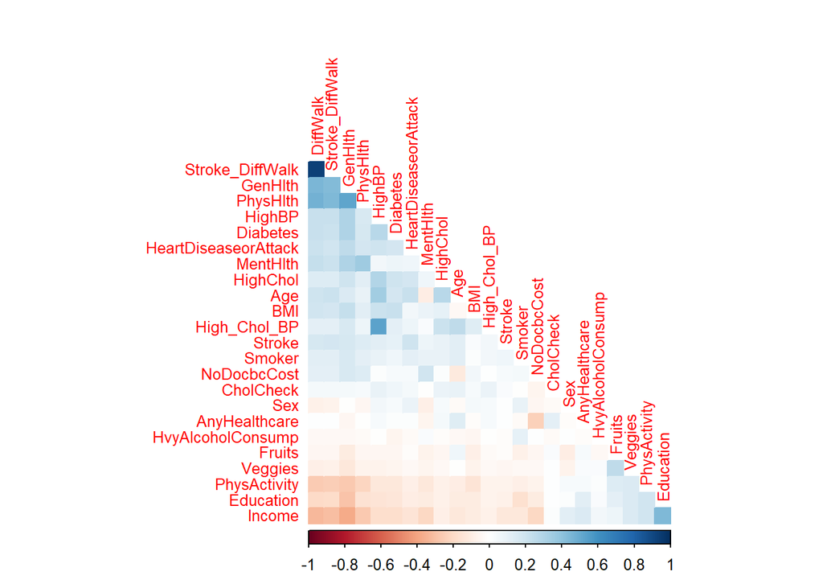

```r
correlation_matrix <- cor(df)
corrplot(correlation_matrix, method = 'color', order = 'FPC', type = 'lower', diag = FALSE,
         tl.cex = 0.8, # Tamaño de las etiquetas de texto
         cl.cex = 0.8, # Tamaño de la leyenda de colores
         number.cex = 0.7) # Tamaño de los números de correlación
```

Una vez más realizamos las correlaciones para observar si con las dos nuevas columnas tiene una relación más fuerte como lo es la lineal o solo existe dependencia pero no lineal entre ellas y esto ultimo fue lo concluido.